# Burundi

Institutionel

*Les perceptions globales de la Croix-Rouge du Burundi sont très positives, avec des évaluations constamment élevées tant pour les compétences que pour les valeurs. La capacité et le respect obtiennent les scores les plus élevés, tandis que l’efficacité, l’engagement et la transparence affichent des scores comparativement plus faibles, tout en restant positifs. Le niveau de confiance est globalement homogène entre les provinces et les différents groupes démographiques, avec seulement de faibles variations. En revanche, les répondants ayant déjà été en contact avec la Croix-Rouge du Burundi, en particuliers, les volontaires, bénéficiaires, donateurs et personnes ayant interagi avec ses services ou activités, déclarent systématiquement des niveaux de confiance plus élevés que ceux n’ayant eu aucun engagement préalable.*

**Points clés**

- Niveau de confiance élevé : les répondants expriment des perceptions très positives de la Croix-Rouge du Burundi dans l’ensemble des dimensions liées aux compétences et aux valeurs.
- Faibles différences démographiques : les niveaux de confiance restent globalement similaires entre les provinces, les groupes d’âge, les genres et les niveaux d’éducation, indiquant que les perceptions positives sont largement partagées.
- L’engagement renforce la confiance : les personnes ayant déjà interagi avec la Croix-Rouge du Burundi attribuent des scores plus élevés, tant pour les compétences que pour les valeurs. Les écarts les plus importants sont observés entre les répondants ayant déjà eu un engagement avec l’organisation et ceux n’en ayant jamais eu.

# Échantillonnage

L’enquête a été menée dans cinq provinces du Burundi : Buhumuza, Bujumbura, Burunga, Butanyerera et Gitega.

Une méthode d’échantillonnage stratifié a été utilisée afin d’assurer une large représentativité géographique tout en couvrant les principaux groupes de population.

- Couverture géographique **:** l’échantillon assure une bonne couverture des cinq provinces. Par rapport aux estimations de la population nationale, Buhumuza, Burunga et Butanyerera sont légèrement surreprésentées, tandis que Bujumbura et Gitega sont quelque peu sous-représentées.
- Âge et genre **:** la répartition par âge et par sexe reflète globalement celle de la population nationale, bien que les adultes âgés de 30 à 49 ans soient légèrement surreprésentés et ceux âgés de 20 à 29 ans sous-représentés.
- Éducation **:** le profil éducatif est globalement comparable à celui de la population nationale, avec une proportion plus élevée de répondants ayant suivi un enseignement primaire (49,7 % contre 41,4 %) et une proportion plus faible de personnes sans éducation formelle (27,6 % contre 38,2 %). Les proportions de personnes ayant suivi un enseignement secondaire ou universitaire sont proches des estimations nationales.

## Distribution géographique

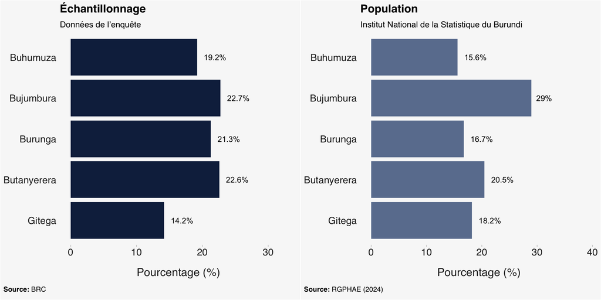

## Couverture

[interactive chart not shown]

## Genre et âge

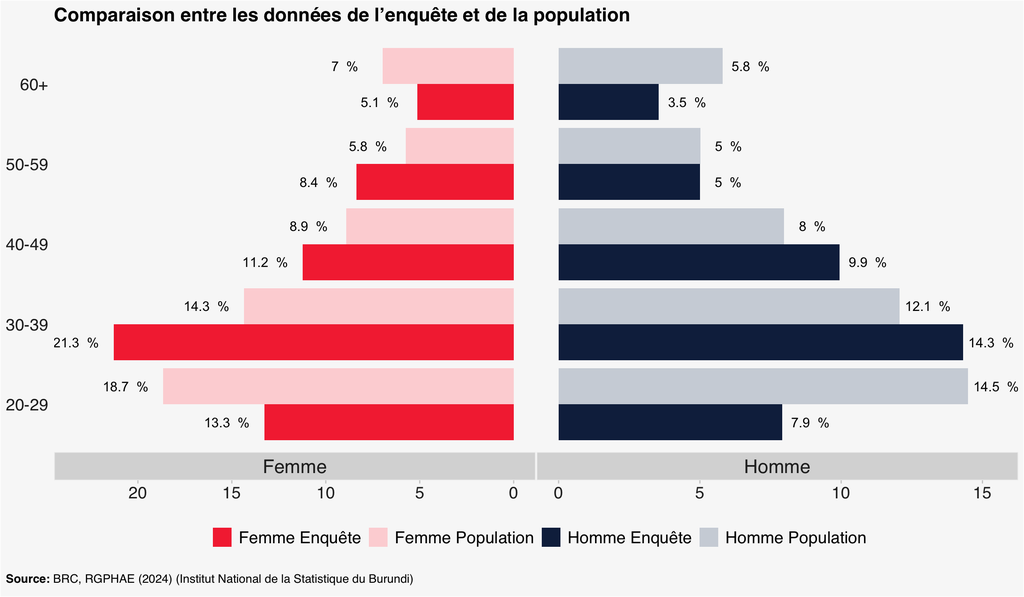

## Education

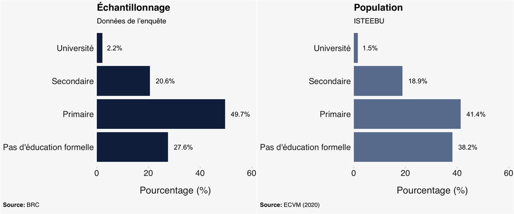

## Limitations

Bien que l’échantillon assure une large couverture des cinq provinces, certaines différences avec la structure de la population doivent être prises en compte dans l’interprétation des résultats. Bujumbura et Gitega sont sous-représentées, tandis que Buhumuza, Burunga et Butanyerera sont légèrement surreprésentées. Des écarts sont également observés selon l’âge, le genre et le niveau d’éducation, notamment une surreprésentation des 30–49 ans et des personnes ayant un niveau d’éducation primaire.

Par ailleurs, une proportion importante des répondants avait déjà été en contact avec la Croix-Rouge du Burundi, notamment comme bénéficiaire ou volontaire. Comme ces personnes tendent à exprimer des niveaux de confiance plus élevés, cela peut contribuer à une surestimation du niveau global de confiance. Les résultats doivent donc être interprétés en tenant compte de ces différences entre l’échantillon et la population générale.

# Résultats de l’enquête

Les graphiques ci-dessous présentent les réponses à l’enquête sous forme de pourcentages, offrant une représentation visuelle des niveaux de confiance des communautés pour les différentes sous-dimensions. Ils illustrent la répartition des perceptions des communautés concernant les compétences et les valeurs.

## Perception de la confiance

### Compétences

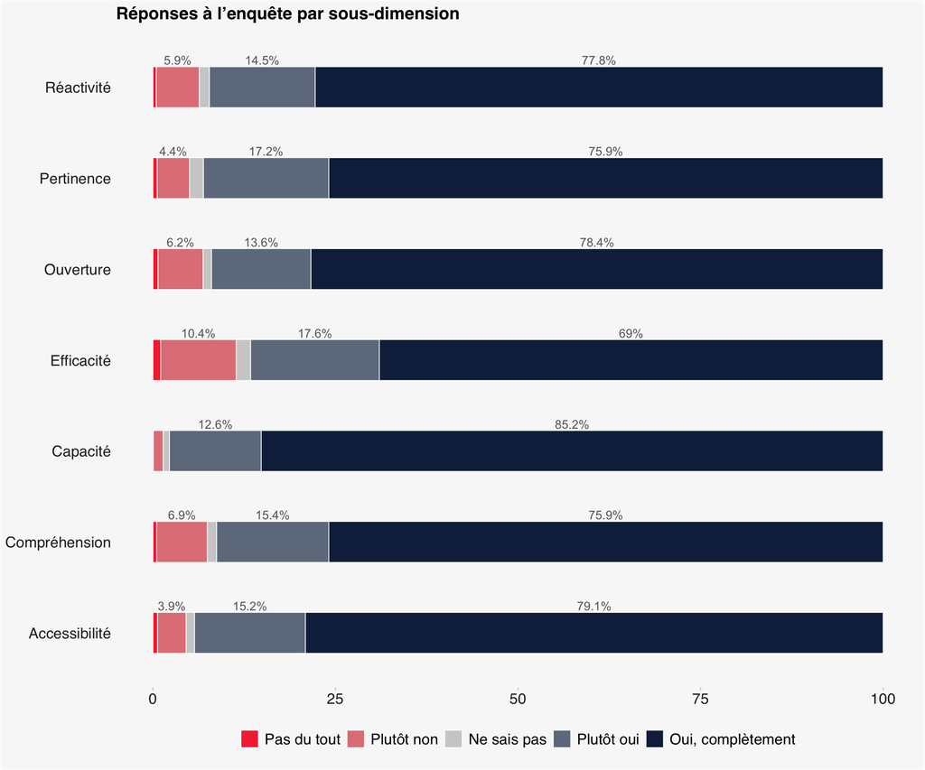

### Valeurs

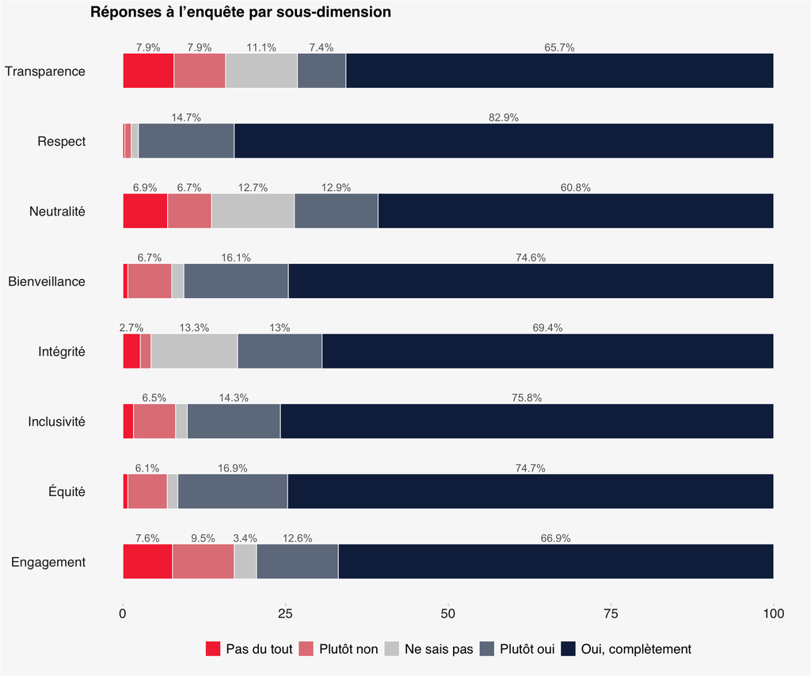

## Questions contextuelles

Cette section présente les résultats relatifs aux expériences des membres de la communauté avec la Croix-Rouge ainsi qu’à leurs comportements à son égard. Ces questions explorent les interactions, les perceptions et les modes d’engagement, afin de mieux comprendre comment la Croix-Rouge est perçue et sollicitée au sein des communautés.

### Expériences

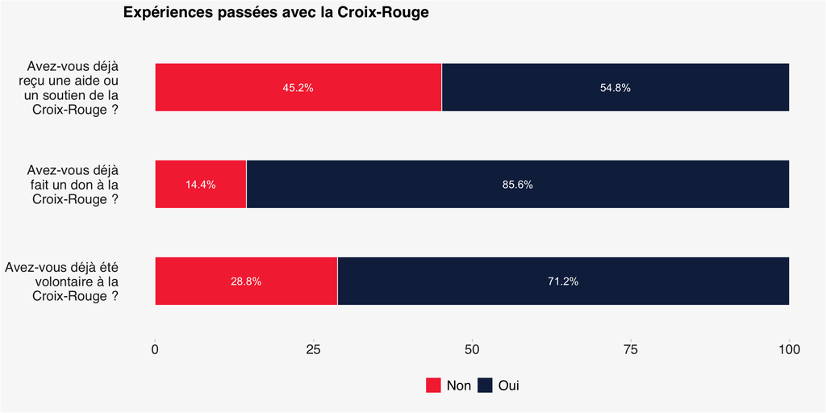

### Comportements

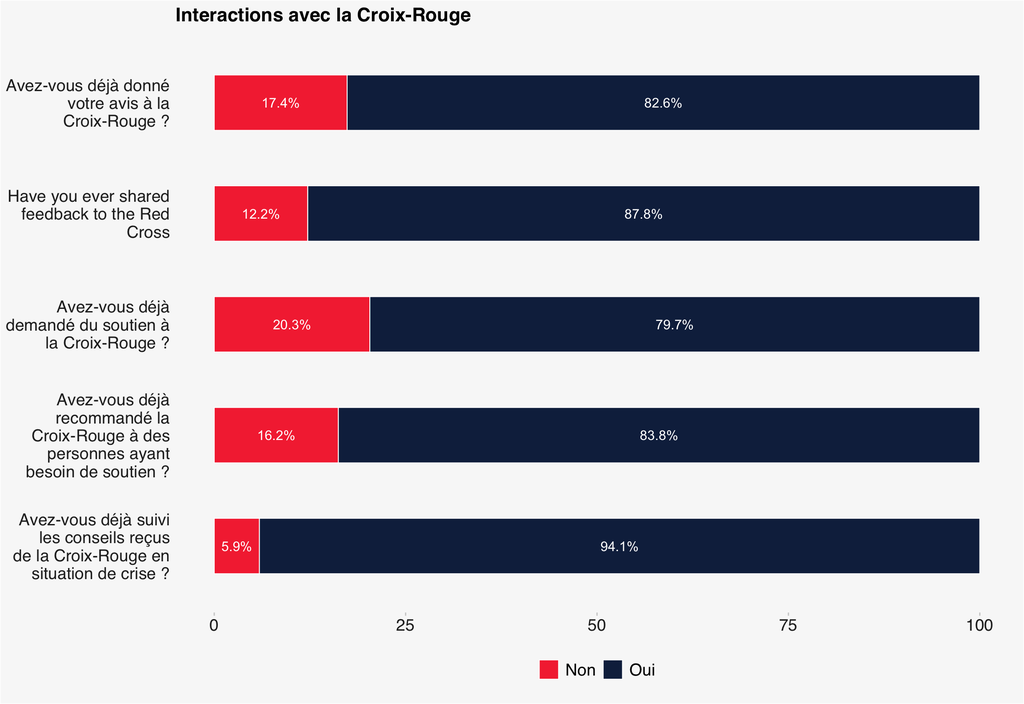

### Intentions

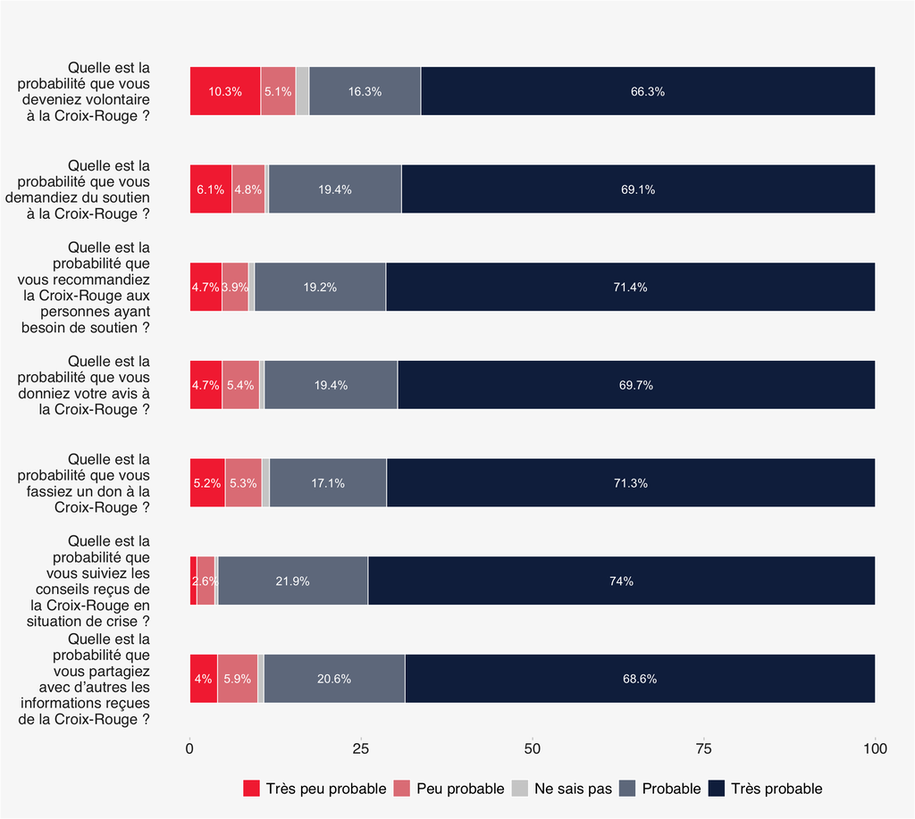

# Scores

Ce score est calculé à partir des réponses aux questions évaluant les perceptions relatives aux compétences et aux valeurs, afin de fournir une mesure globale de la confiance. Un score plus élevé indique un niveau de confiance plus important, suggérant que les membres de la communauté considèrent que leurs besoins sont pris en compte et que leurs valeurs sont respectées.

*En savoir plus sur la méthode de calcul des scores : Méthodes*

## Score global

La Croix-Rouge du Burundi obtient des évaluations élevées dans l’ensemble des dimensions liées aux compétences et aux valeurs. La capacité et le respect constituent les dimensions les mieux évaluées, tandis que l’engagement et la transparence présentent les principales possibilités d’amélioration.

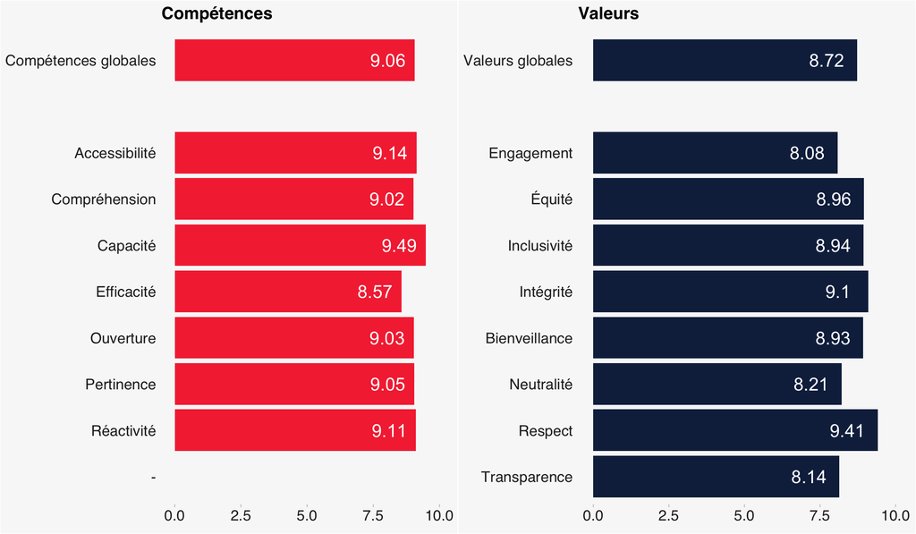

## Score par facteurs

*Distribution des scores moyens pour les compétences et valeurs par questions socio-démographiques*

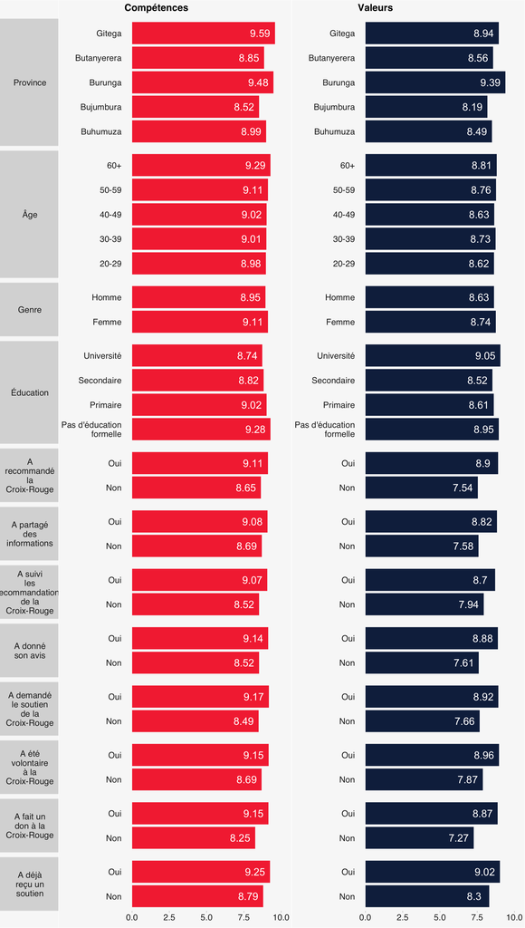

## Score par profil des répondants

Les perceptions relatives aux compétences et aux valeurs restent élevées quel que soit le niveau d’engagement. Les répondants ayant été volontaires ou ayant bénéficié du soutien de la Croix-Rouge du Burundi tendent à évaluer l’organisation légèrement plus positivement que ceux n’ayant pas eu d’engagement préalable. Le niveau de confiance reste néanmoins élevé dans l’ensemble des groupes.

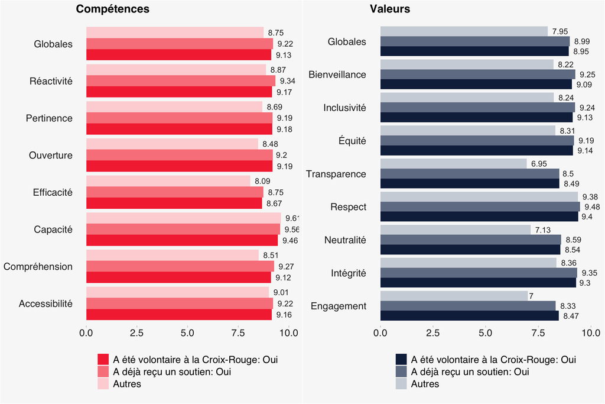

# Méthodes et indicateurs

## Méthodes

**Méthodologie de calcul des scores**

Pour déterminer les scores, nous utilisons la méthode suivante :

1. **Structure de l’enquête**

   L’enquête CTI comprend plusieurs questions regroupées en sous-dimensions au sein de deux catégories principales :
   - Compétences (par ex. fiabilité, efficacité, capacité technique)
   - Valeurs (par ex. éthique, intégrité, équité, transparence)
2. **Calcul des scores des sous-dimensions**

   Chaque sous-dimension comprend plusieurs items (questions). Les répondants utilisent une échelle de type Likert de 1 à 4 ; les réponses « Ne sait pas » sont exclues.

   Pour chaque sous-dimension :

   *Score de la sous-dimension = ∑ (Scores pondérés des réponses) / Nombre d’items*

   Si les pondérations ne sont pas déterminées empiriquement, une pondération égale est généralement appliquée à chaque item.
3. **Calcul des scores des dimensions**

   Une fois les scores de toutes les sous-dimensions calculés, les scores de Compétences et de Valeurs correspondent à la moyenne arithmétique des scores de leurs sous-dimensions respectives :
   - *Score de Compétences = ∑ (Scores des sous-dimensions de Compétences) / n*
   - *Score de Valeurs = ∑ (Scores des sous-dimensions de Valeurs) / m*

   où *n* et *m* correspondent au nombre de sous-dimensions dans chaque catégorie.

## Indicateurs

### Genre

Répondants par genre

| Genre | Nombre total de répondants | Pourcentage (%) |
| --- | --- | --- |
| Femme | 1019 | 59.3 |
| Homme | 700 | 40.7 |
| Autre ou sans réponse | 0 | 0.0 |
| Total | 1719 | 100.0 |

### Groupe d’âge

Répondants par groupe d’âge

| Groupe d’âge | Nombre total de répondants | Pourcentage (%) |
| --- | --- | --- |
| 20-29 | 364 | 21.2 |
| 30-39 | 612 | 35.6 |
| 40-49 | 364 | 21.2 |
| 50-59 | 230 | 13.4 |
| 60+ | 149 | 8.7 |
| Total | 1719 | 100.0 |

### Géographique

Province et Commune

| Province | Commune | Nombre total de répondants | Pourcentage (%) |
| --- | --- | --- | --- |
| Buhumuza | Total | 330 | 100.0 |
| Buhumuza | Butihinda | 190 | 57.6 |
| Buhumuza | Gisuru | 140 | 42.4 |
| Bujumbura | Total | 391 | 100.0 |
| Bujumbura | Mpanda | 160 | 40.9 |
| Bujumbura | Bukinanyana | 129 | 33.0 |
| Bujumbura | Muhuta | 54 | 13.8 |
| Bujumbura | Rwibaga | 48 | 12.3 |
| Burunga | Total | 366 | 100.0 |
| Burunga | Nyanza | 202 | 55.2 |
| Burunga | Makamba | 164 | 44.8 |
| Butanyerera | Total | 388 | 100.0 |
| Butanyerera | Kayanza | 134 | 34.5 |
| Butanyerera | Matongo | 131 | 33.8 |
| Butanyerera | Tangara | 121 | 31.2 |
| Butanyerera | Kirundo | 1 | 0.3 |
| Butanyerera | Muhanga | 1 | 0.3 |
| Gitega | Total | 244 | 100.0 |
| Gitega | Gishubi | 99 | 40.6 |
| Gitega | Nyabihanga | 82 | 33.6 |
| Gitega | Kiganda | 62 | 25.4 |
| Gitega | Gitega | 1 | 0.4 |

## Pondération

**Pondération vs. données non pondérées**

Afin de corriger les écarts démographiques entre l’échantillon et la population globale, nous avons appliqué une technique appelée *raking*. Cette méthode ajuste les résultats à partir de variables telles que l’âge, le genre, la province, le niveau d’éducation et la zone géographique (urbaine/rurale), afin d’aligner l’échantillon sur la distribution de la population.

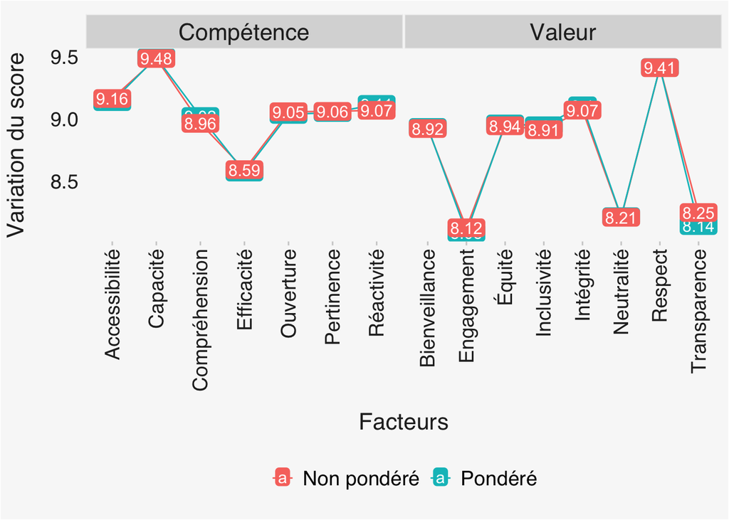

## Corrélation

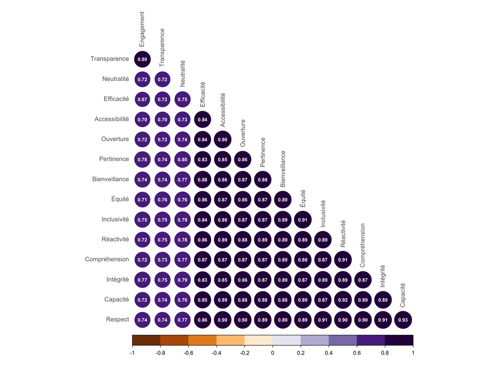

**Comment lire la matrice de corrélation**

1. **Repérez la ligne et la colonne**

   Les valeurs vont de –1 à +1.

**Interprétation**

| Valeur | Signification |
| --- | --- |
| 0,00 | Aucune relation |
| 0,10–0,30 | Faible |
| 0,30–0,50 | Légère |
| 0,50–0,70 | Modérée |
| 0,70–1,00 | Forte |
| Valeurs négatives | Les variables évoluent dans des directions opposées |

## Tests de significativité

**Tests de significativité**

Le tableau indique si les résultats des bénéficiaires, des volontaires et des autres répondants diffèrent significativement les uns des autres. Nous utilisons un niveau de confiance de 95 % et ajustons les valeurs p afin de tenir compte des comparaisons multiples.

| Dimension | Drivers | A été volontaire à la Croix-Rouge: Oui - A déjà reçu un soutien: Oui | A été volontaire à la Croix-Rouge: Oui - Others | A déjà reçu un soutien: Oui - Others |
| --- | --- | --- | --- | --- |
| Compétence | Capacité | Non | Non | Non |
| Compétence | Réactivité | Oui | Oui | Oui |
| Compétence | Compréhension | Non | Oui | Oui |
| Compétence | Accessibilité | Non | Non | Non |
| Compétence | Ouverture | Non | Oui | Oui |
| Compétence | Pertinence | Non | Oui | Oui |
| Compétence | Efficacité | Non | Oui | Oui |
| Valeur | Bienveillance | Non | Oui | Oui |
| Valeur | Équité | Non | Oui | Oui |
| Valeur | Inclusivité | Non | Oui | Oui |
| Valeur | Respect | Non | Non | Non |
| Valeur | Engagement | Non | Oui | Oui |
| Valeur | Intégrité | Non | Oui | Oui |
| Valeur | Transparence | Non | Oui | Oui |
| Valeur | Neutralité | Non | Oui | Oui |

# Télécharger

Télécharger le fichier Excel de synthèse